# Lista de Proyectos

Aquí encontraras todos los proyectos relacionados con ciencia de datos, estadística, visualización y creación de modelos para datos de mi portafolio hasta la fecha en formato de página web.

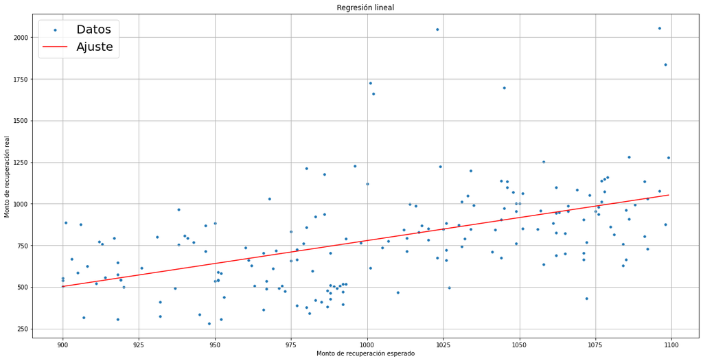

### Efectividad de una Estrategía con Regresión Lineal:

Se analizó un caso de un banco que buscaba recuperar fondos de deudores morosos mediante una estrategia dividida por grados de morosidad. Se realizó un estudio estadístico previo y se empleó una regresión lineal para evaluar la efectividad de la estrategia. Haz click aquí para ver el proyecto

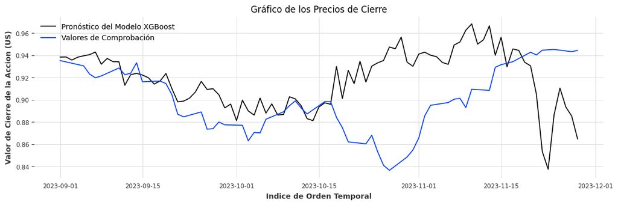

### Pronóstico de Series de Tiempo mediante XGBoost:

A partir de los datos históricos OHLCV del índice Standard & Poor’s 500, buscamos un modelo de series de tiempo capaz de pronosticar sus respectivos valores de cierre en el mercado. Para ello, probamos modelos clásicos y el modelo de aprendizaje automático de regresión XGBoost. Haz click aquí para ver el proyecto

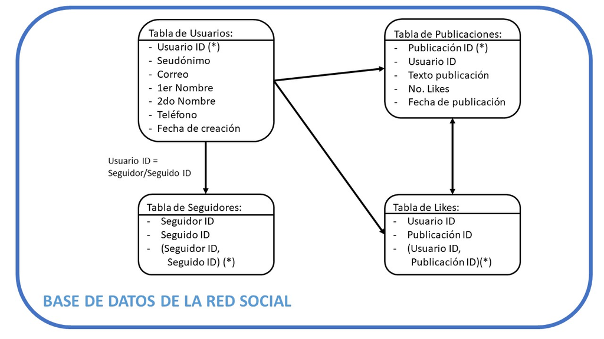

### Base de Datos Relacionales con SQLite3:

Se presenta un ejemplo de base de datos relacionales simple para una red social ficticia, que incluye usuarios, seguidores, publicaciones y likes. Se construyó utilizando Python y SQL, este último implementado a través del módulo sqlite3. Haz click aquí para ver el proyecto

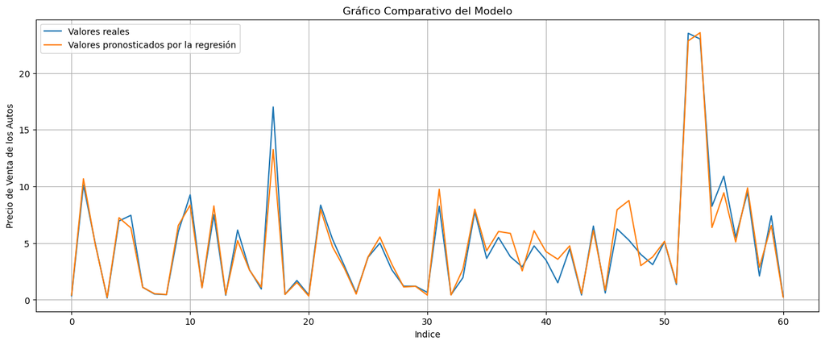

### Predicción de Precios utilizando Bosque Aleatorio:

En este proyecto, buscamos construir un modelo de pronóstico para los precios de venta de autos en un concesionario de la India, a partir de otros datos del concesionario y de los propios autos. Dicho modelo se basa en una regresión de bosque aleatorio, que es un bagging o bootstrap del método de regresión de árboles de decisión. Haz click aquí para ver el proyecto